# Comparison of CTCF consensus found in the (mutation-induced) Gained, Lost and stable binding sites: a descriptive analysis

# 4 Comparing the identified CTCF-like consensus in the three cluster, in a **21 bp** window

In this section, I will look into the identified CTCF-like censensus in the *Gained*, *Lost*, and *Stable* cluster and compare their binding site orientation, and their nucleotide distribution in a longer window (21bp) centered at the mid-point of the canonical CTCF motif, i.e the 10th nucleotide (‘G’) in the CTCF logo in Fig. 1.

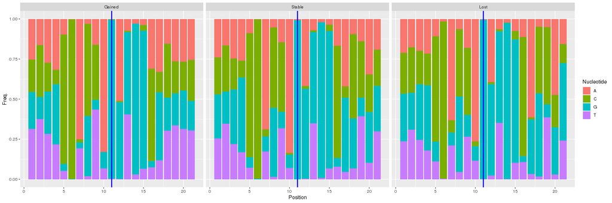

Fig 6: Necleotide distribution in a 21bp window centered at the mid-point of the canonical CTCF motif for binding sequences in cluster Gained, stable and lost. The vertical blue line indicates the center which corresponds to the 10th nucleotide (‘G’) in Fig 1.

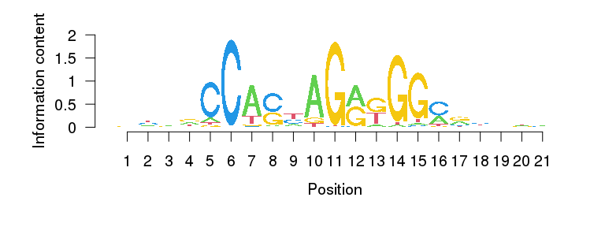

Fig 7: sequence logo of the CTCF motif identifed in the **Gained** Cluster

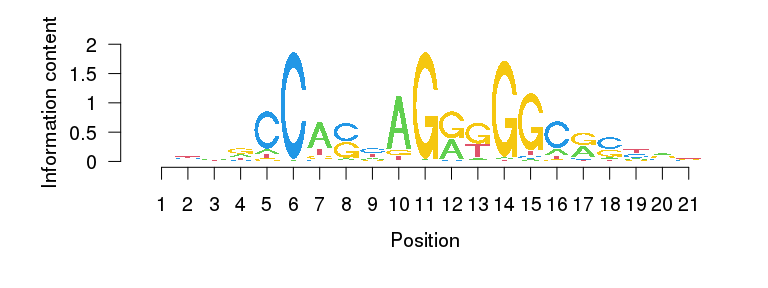

Fig 8: sequence logo of the CTCF motif identifed in the **Stable** Cluster

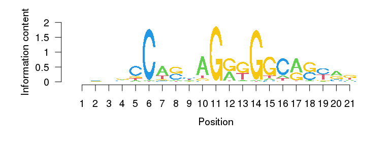

Fig 9: sequence logo of the CTCF motif identifed in the **Lost** Cluster

# 5 Comparing the identified CTCF-like consensus in the three cluster, in a **41 bp** window

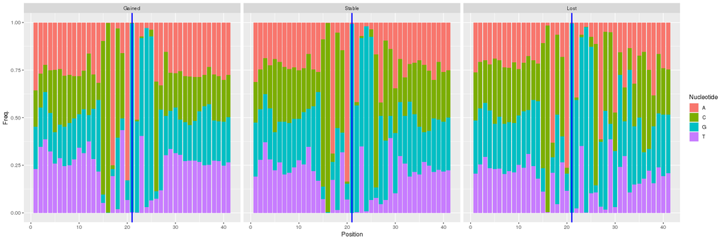

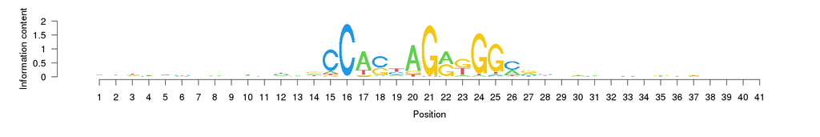

Fig 11: sequence logo of the CTCF motif identifed in the **Gained** Cluster

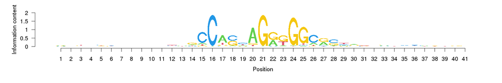

Fig 12: sequence logo of the CTCF motif identifed in the **Stable** Cluster

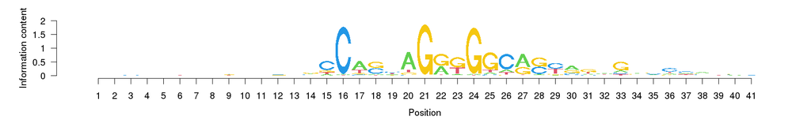

Fig 13: sequence logo of the CTCF motif identifed in the **Lost** Cluster

# 6 Comparing the identified CTCF-like consensus in the three cluster, in a **61 bp** window

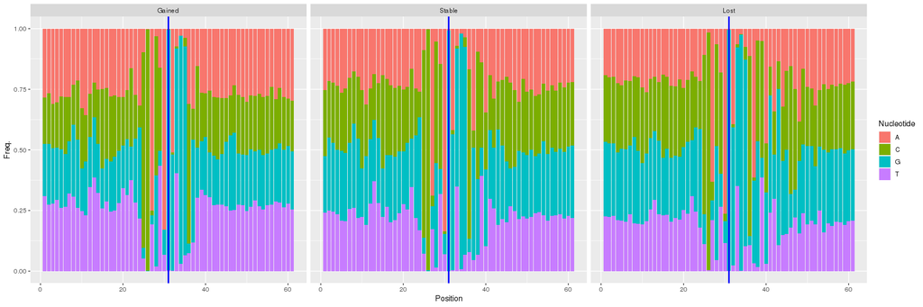

Fig 14: Necleotide distribution in a 61bp window centered at the mid-point of the canonical CTCF motif for binding sequences in cluster Gained, stable and lost. The vertical blue line indicates the center which corresponds to the 10th nucleotide (‘G’) in Fig 1.

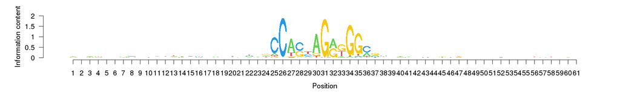

Fig 15: sequence logo of the CTCF motif identifed in the **Gained** Cluster

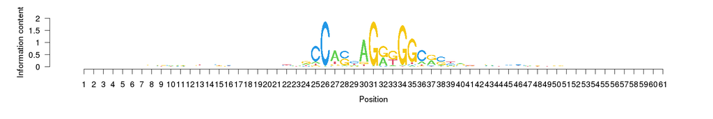

Fig 16: sequence logo of the CTCF motif identifed in the **Stable** Cluster

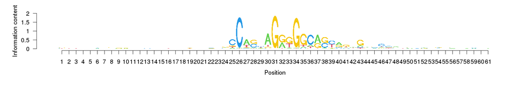

Fig 17: sequence logo of the CTCF motif identifed in the **Lost** Cluster

# 7 Frequency differences

## 7.1 **Lost** v.s. **Stable**

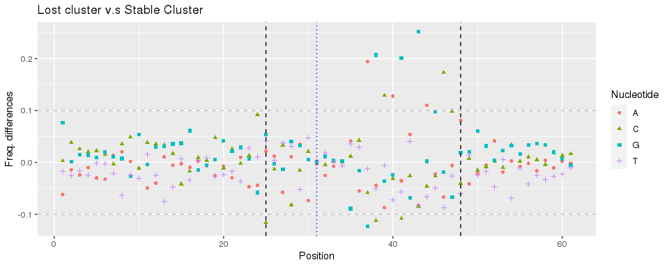

Fig 18: Difference of nucleotide differences between the **Lost** and **Stable** clusters. Black dashed lines (at position 25 and 48) are the boundaries of the region with frequency differences greater than 10% between the Lost cluster and the stable cluster

Nucleotide frequences at positions with Freq. differences greater than 10% between the **Lost** and **Stable** clusters.

| Nucleotide | Position | Gained | Stable | Lost | lost-stable | Gained-stable |
| --- | --- | --- | --- | --- | --- | --- |
| G | 43 | 0.188 | 0.3939 | 0.6458 | 0.2519 | -0.2059 |
| G | 38 | 0.2077 | 0.3118 | 0.5189 | 0.2071 | -0.1041 |
| G | 41 | 0.1862 | 0.2821 | 0.4827 | 0.2006 | -0.09588 |
| A | 37 | 0.3295 | 0.4201 | 0.6145 | 0.1944 | -0.09063 |
| C | 46 | 0.1638 | 0.3537 | 0.5269 | 0.1732 | -0.1899 |
| C | 39 | 0.2005 | 0.3528 | 0.4819 | 0.1291 | -0.1523 |
| A | 40 | 0.2659 | 0.3459 | 0.4739 | 0.128 | -0.07996 |
| G | 37 | 0.4235 | 0.4638 | 0.3406 | -0.1232 | -0.0403 |
| C | 25 | 0.8057 | 0.7729 | 0.657 | -0.1159 | 0.0328 |
| C | 38 | 0.3348 | 0.5266 | 0.4145 | -0.1122 | -0.1918 |
| A | 44 | 0.2856 | 0.2105 | 0.3205 | 0.11 | 0.07511 |
| C | 41 | 0.2534 | 0.2279 | 0.1197 | -0.1083 | 0.02541 |

## 7.2 **Gained** v.s. **Stable**

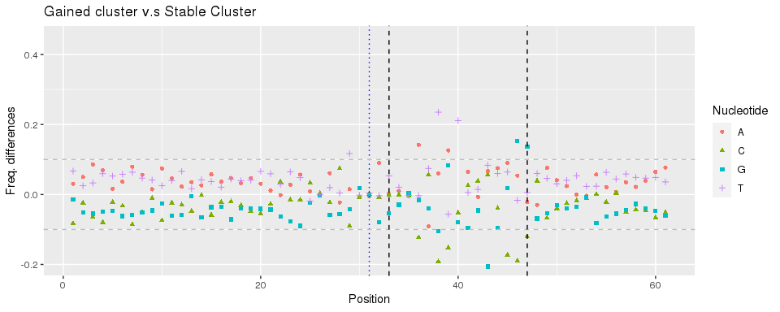

Nucleotide frequences at positions with Freq. differences greater than 10% between the Gained cluster and the Stable cluster.

| Nucleotide | Position | Gained | Stable | Lost | lost-stable | Gained-stable |
| --- | --- | --- | --- | --- | --- | --- |
| T | 38 | 0.3026 | 0.06725 | 0.01687 | -0.05038 | 0.2353 |
| T | 40 | 0.3133 | 0.1022 | 0.02972 | -0.07246 | 0.2112 |
| G | 43 | 0.188 | 0.3939 | 0.6458 | 0.2519 | -0.2059 |
| C | 38 | 0.3348 | 0.5266 | 0.4145 | -0.1122 | -0.1918 |
| C | 46 | 0.1638 | 0.3537 | 0.5269 | 0.1732 | -0.1899 |
| C | 45 | 0.1782 | 0.3511 | 0.3245 | -0.02659 | -0.1729 |
| G | 46 | 0.3098 | 0.1572 | 0.1382 | -0.01905 | 0.1526 |
| C | 39 | 0.2005 | 0.3528 | 0.4819 | 0.1291 | -0.1523 |
| A | 36 | 0.3098 | 0.1677 | 0.1124 | -0.05524 | 0.1421 |
| G | 47 | 0.3187 | 0.1825 | 0.1157 | -0.06687 | 0.1362 |
| A | 39 | 0.2641 | 0.138 | 0.0506 | -0.08739 | 0.1261 |
| C | 36 | 0.5765 | 0.6996 | 0.7422 | 0.04261 | -0.123 |
| C | 47 | 0.1961 | 0.3162 | 0.4153 | 0.0991 | -0.1201 |
| T | 29 | 0.4342 | 0.317 | 0.2651 | -0.05197 | 0.1172 |
| G | 38 | 0.2077 | 0.3118 | 0.5189 | 0.2071 | -0.1041 |

## 7.3 Nucleotide frequencies in a **24 bp** window (this region has Freq. differences greater than 10%)

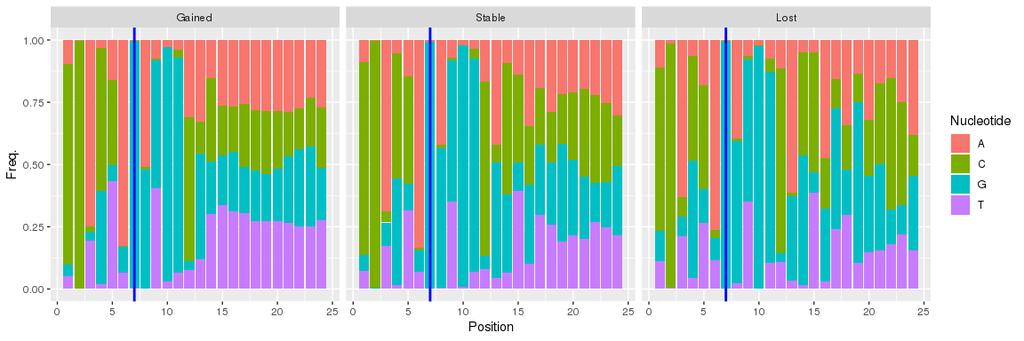

Fig 20: Necleotide distribution in a window for binding sequences in cluster Gained, stable and lost. The vertical blue line indicates the center which corresponds to the 10th nucleotide (‘G’) in Fig 1.

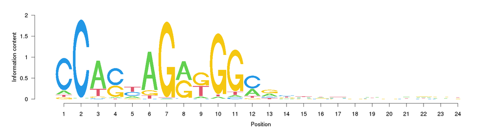

Fig 21: sequence logo of the CTCF motif identifed in the **Gained** Cluster

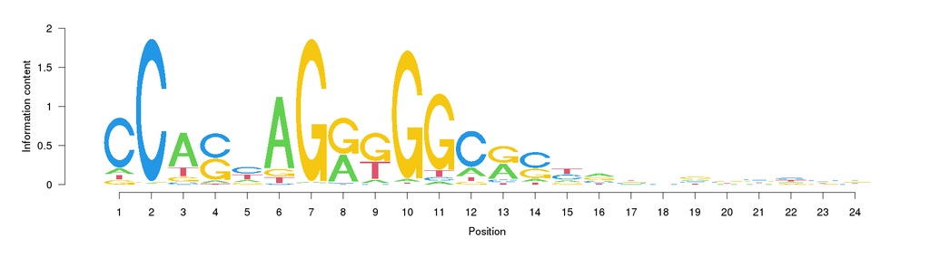

Fig 22: sequence logo of the CTCF motif identifed in the **Stable** Cluster

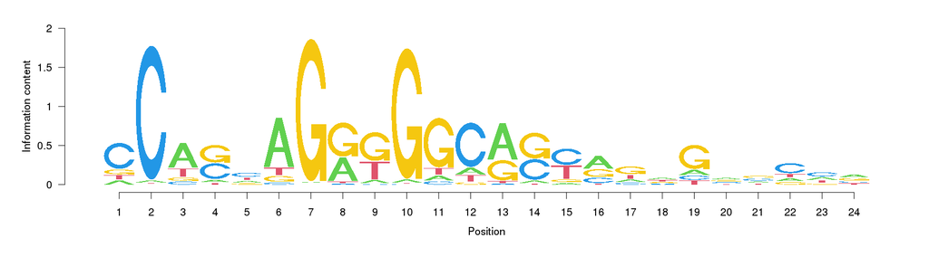

Fig 23: sequence logo of the CTCF motif identifed in the **Lost** Cluster